# MATH 216 HW 2

MJ Pascual

September 26, 2017

```r
library(tidyverse)
```

```r
library(ggplot2)
taboo <- read.csv("Taboo.csv")
```

## Question 1

```r
taboo %>%
  group_by(Gender) %>%
  summarize(avg.sex = mean(Sex))
```

```
## # A tibble: 2 x 2
##   Gender  avg.sex
##   <fctr>    <dbl>
## 1      F 2.562500
## 2      M 2.038462
```

The mean doesn’t show any significant difference between genders.

## Question 2

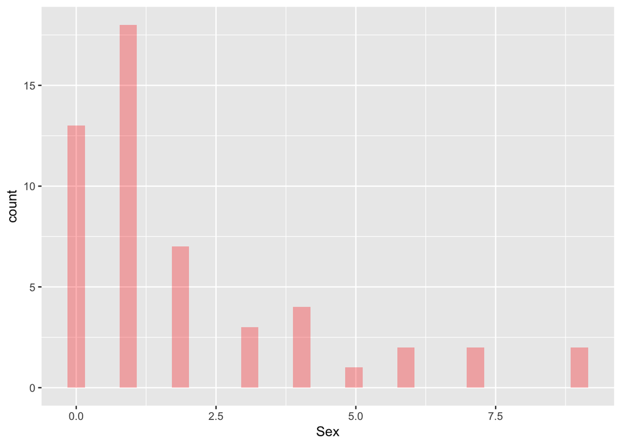

```r
males <- subset(taboo, Gender == "M")
females <- subset(taboo, Gender == "F")

ggplot(taboo, mapping = aes(Sex)) +
  geom_histogram(data = males, aes(Sex), fill ="red", alpha = .3)
```

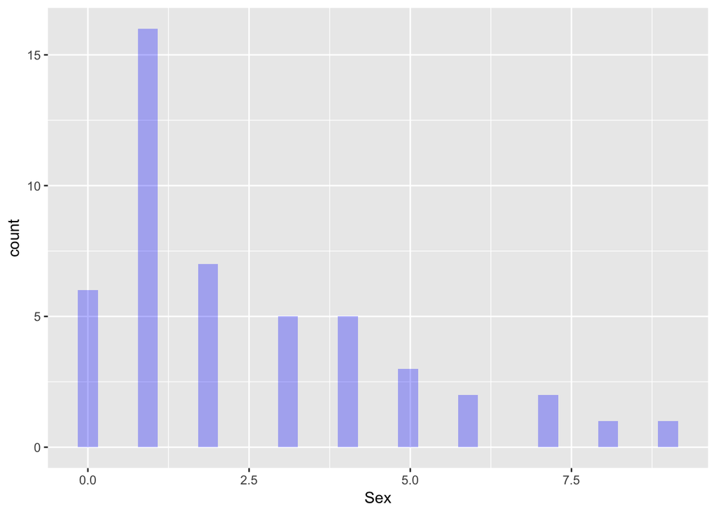

```r
  ggplot(taboo, mapping = aes(Sex)) +
  geom_histogram(data = females, aes(Sex), fill ="blue", alpha = .3)
```

The distributions of both graphs show that there are more men who don’t have sex or have sex at least once than women who don’t have sex. The female variable is more spread out in its distribution.

## Question 3

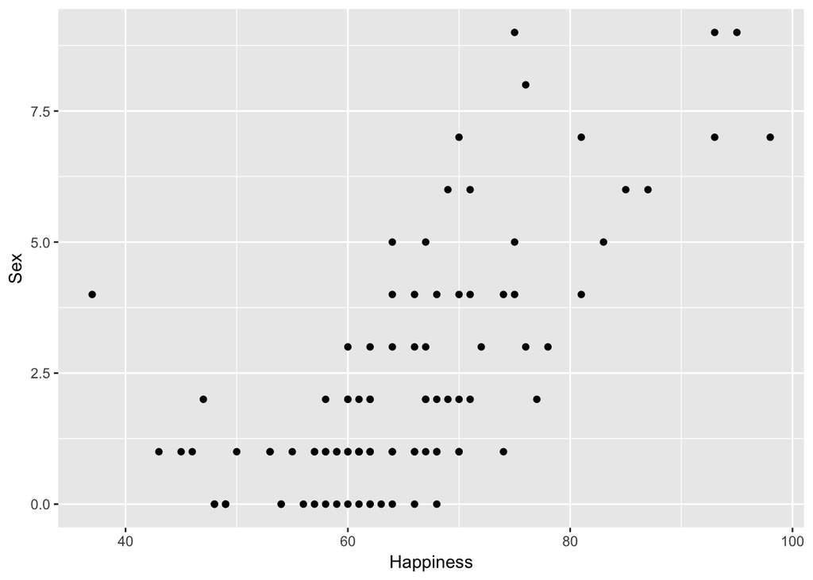

```r
males <- subset(taboo, Gender == "M")
females <- subset(taboo, Gender == "F")

ggplot(data = taboo, mapping = aes(x = Happiness, y = Sex)) + geom_point()
```

## Question 4

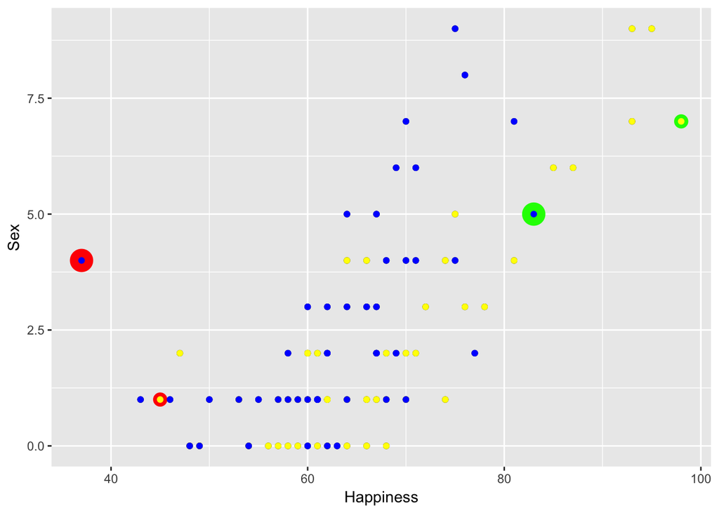

```r
happiest.female <- filter(taboo, ID == 51)
saddest.female <- filter(taboo, ID == 27)
happiest.male <- filter(taboo, ID == 41)
saddest.male <- filter(taboo, ID == 33)

taboo %>%
  group_by(Gender) %>%
  arrange(Happiness) %>%
  ggplot(mapping = aes(Happiness, Sex)) + geom_point() +
  geom_point(data = happiest.female, color = "green", size = 7) +
  geom_point(data = happiest.male, color = "green", size = 4) +
  geom_point(data = saddest.female, color = "red", size = 7) +
  geom_point(data = saddest.male, color = "red", size = 4) +
  geom_point(data = males, color = "yellow") +
  geom_point(data = females, color = "blue")
```

## Question 5

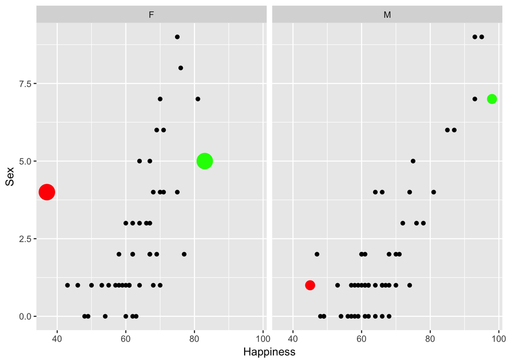

```r
taboo %>%
ggplot(aes(x = Happiness, y = Sex)) + geom_point() +
   geom_point(data = happiest.female, color = "green", size = 7) +
  geom_point(data = happiest.male, color = "green", size = 4) +
  geom_point(data = saddest.female, color = "red", size = 7) +
  geom_point(data = saddest.male, color = "red", size = 4) +
  facet_wrap(~Gender)
```

I prefer 5 because it allows me to see similarities, but more importantly differences between females and males more clearly than number 4.

## Question 6

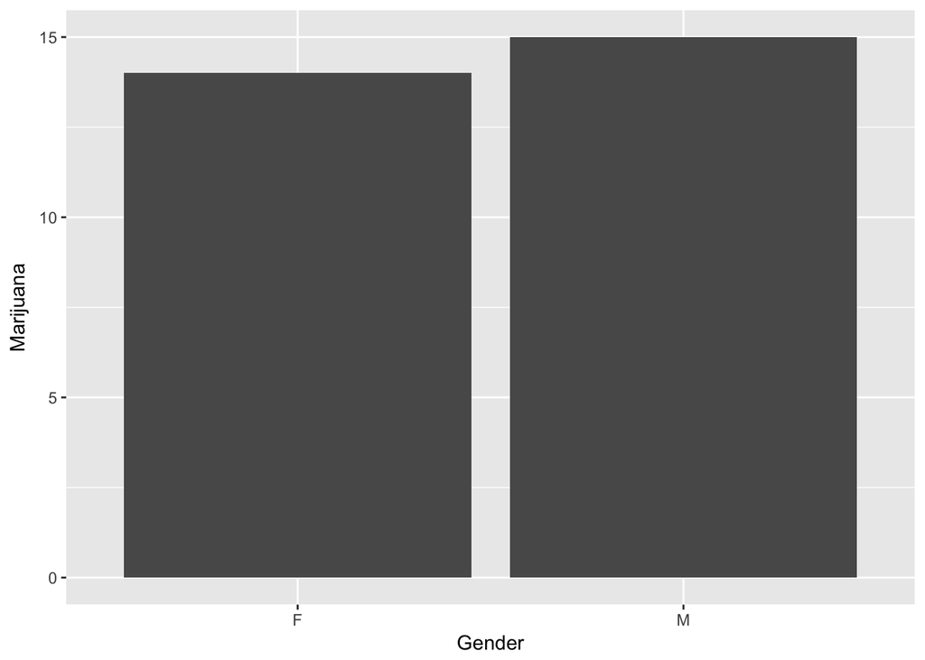

```r
taboo %>%
  group_by(Gender) %>%
  ggplot(mapping = aes(x = Gender, y = Marijuana)) +
  geom_bar(stat = "identity")
```

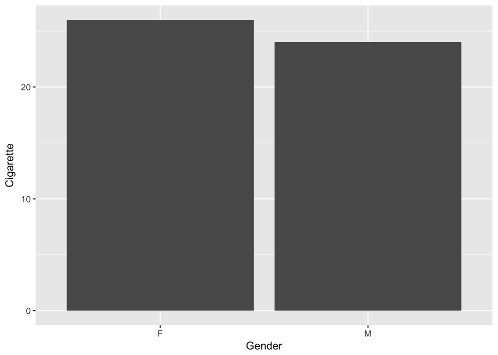

```r
taboo %>%
  group_by(Gender) %>%
  ggplot(mapping = aes(x = Gender, y = Cigarette)) +
  geom_bar(stat = "identity")
```

There is no clear evidence between differences in cigarette and weed consumption by gender, they’re almost the same even when looking at the mean.

## Question 7

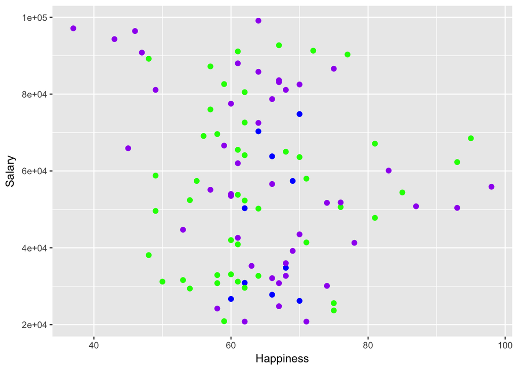

```r
no.alc <-
  taboo %>%
    filter(Alcohol == 0)
few.alc <-
  taboo %>%
    filter(Alcohol >= 1 & Alcohol <= 3)
lots.alc <-
  taboo %>%
    filter(Alcohol > 3)

taboo %>%
  ggplot(mapping = aes(Happiness, Salary)) + geom_point() +
    geom_point(data = no.alc, color = "blue", size = 2) +
    geom_point(data = few.alc, color = "green", size = 2) +
    geom_point(data = lots.alc, color = "purple", size = 2)
```

People who didn’t consume alcohol didn’t make as much money as other people. The happiness of people who drink a lot of alcohol is more distributed than those who drink a little or none. An interesting outlier is the group of people who are rich and drink a lot of alcohol, but are extremely low in terms of happiness.

## Question 8

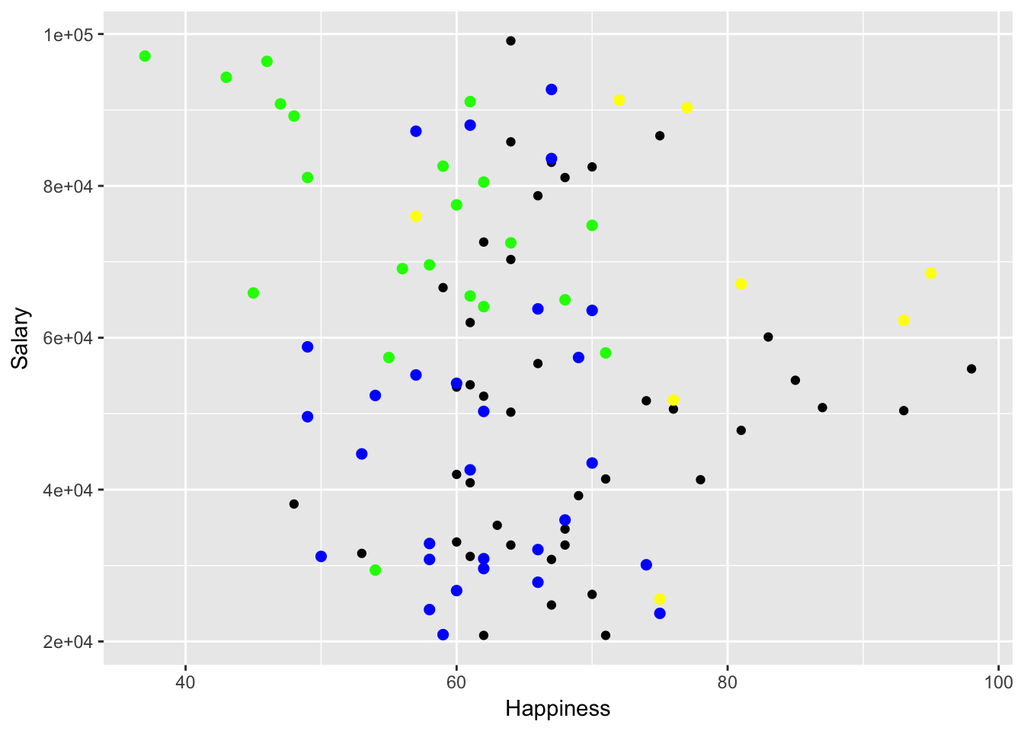

```r
weed.cig <-
  taboo %>%
    filter(Cigarette == 1 & Marijuana == 1)

cig <-
  taboo %>%
    filter(Cigarette == 1 & Marijuana == 0)

weed <-
  taboo %>%
    filter(Marijuana == 1 & Cigarette == 0)

taboo %>%
  ggplot(mapping = aes(Happiness, Salary)) + geom_point() +
    geom_point(data = weed, color = "yellow", size = 2) +
    geom_point(data = cig, color = "blue", size = 2) +
    geom_point(data = weed.cig, color = "green", size = 2)
```

## General

Men and women have slightly differences in how much sex they have per week based on distribution. A common trend was that there is a relationship between how much sex someone has and their happiness, especially with males. The differences between men and women in terms of happiness can be explained with the fact that a woman’s happiness is more emotional than physical. Additionally, there was no differences between men and women in terms of drug consumption, however there was a relationship found between drug consumption and salary. Alcohol consumption, salary, and happiness were all related as well, but no general trend was found for specific variables in terms of how much one drank.